# Strait of Georgia MP evaluation summary

# Background

Pacific Herring (*Clupea pallasii*) fisheries in British Columbia (BC), Canada, have been managed via a management procedure approach since 2017. Management procedures are formal, repeatable rules for deriving harvest advice (usually total allowable catches; TACs) from fishery monitoring data, and are tested against quantitative fishery management objectives in closed loop simulations. Simulation results are often tested against multiple uncertainties by defining multiple simulation scenarios, representing alternative hypotheses about the state of nature. The process of designing, testing, and choosing a management procedure is often called a Management Strategy Evaluation (MSE).

This document summarises closed loop simulations evaluating candidate management procedures for the Strait of Georgia (SOG) herring fishery. SOG herring is the first BC herring fishery to use the new herringoperating model framework, named the Spatially Integrated Statistical Catch-at-Age Herring Operating Model (SISCAH-OM). Although there are several differences between SISCAH and the previous herring assessment and operating models, the main novelty in SISCAH-OM is a depensatory density-dependent mortality (DDM) model, which creates a negative (downward sloping) link between herring natural mortality and biomass, forcing mortality higher when biomass is lower. The SISCAH-OM, including the DDM hypothesis, was accepted as an operating model for all 5 major herring stock assessment regions by Fisheries and Oceans, Canada (DFO) via a regional peer review review process in 2023.

This document summarises simulation tests for a group of candidate SOG management procedures. All candidate MPs are tested against a suite of five SISCAH operating models, which incorporate uncertainty in future productivity at both low and high stock sizes. We first summarise the simulation approach, and then present results averaged (with a weighting) over the five operating models, with some brief discussion of the management implications.

# Simulation approach

## Operating models

We define five SOG Herring operating models that test against uncertainty in productivity at high and low stock sizes. Productivity at high stock sizes is heavily influenced by the $M_b$ parameter, which represents the average mortality rate at very high biomass (generally above unfished levels). At low stock size, productivity is more influenced by the stock-recruit relationship’s steepness parameter $h$, which is the ratio of recruitment at 20% of unfished to the unfished recruitment $R_0$.

We tested three values of each parameter in a cross design (Table 1). Steepness $h$ values were taken across a uniform grid of 0.65, 0.7, and 0.75, while $M_b$ was chosen via a Likelihood Profile approach with a steepness of $h = 0.7$ (Figure 1). The grids for each individual parameter are intersected at their central value, giving a total of five OMs. We are unable to choose a grid of $h$ values via a likelihood profile, as there is limited information in SOG data supporting a single ‘most likely’ steepness value.

OM weighting favours the central OM (called OM1, $M_b=0.562$ and $h = 0.7$) with a weight of 0.34. OM1’s weight is the average of the weights of each axis in the cross desgn, with $h$ being uniform (i.e., 0.33) and the $M_b$ value’s weight based on the relative data likelihood function value (i.e, around 0.35). The remaining operating models are weighted equally across the remaining with a weight of 0.165.

For all operating models, we report leading OM parameters, current biomass and stock status, and $MSY$ based reference points (Table 1).

Table 1: Table 2: SISCAH-OM life-history and management parameter values for stock-recruit steepness ($h$), asymptotic lower limit on depensatory $M$ ($M_b$, /yr), unfished biomass ($SB_0$, kt), unfished recruitment ($R_0$, 1e6), unfished mortality ($M_0$, /yr), mortality depensation rate ($m_1$), time-averaged mortality ($\overline{M}$, /yr), surface survey design catchability ($q_s$), spawning biomass in 2023 ($SB_{2023}/SB_0$), stock status ($P(SB_{2023} > 0.3 SB_0)$), spawning biomass at maximum sustainable yield ($SB_{MSY}$, kt), harvest rate targeting maximum sustainable yield ($U_{MSY}$), maximum sustainable yield ($MSY$), upper stock reference ($USR$, kt), harvest rate targeting the upper stock reference ($U_{USR}$), equilibrium yield at the upper stock reference ($Y_{USR}$), harvest rate associated with negative production and higher risk of extirpation ($U_{Crash}$). Uncertainty is shown as the 95% credible interval where estimates could be drawn from posterior samples (indicated by two parenthetical values), or half the interquartile range where estimates were drawn from 200 year simulations (one parenthetical value).

|  | OM1 | OM2 | OM3 | OM4 | OM5 |
| --- | --- | --- | --- | --- | --- |
| $h$ | 0.70 | 0.65 | 0.75 | 0.70 | 0.70 |
| $M_b$ | 0.562 | 0.562 | 0.562 | 0.532 | 0.584 |
| $SB_0$ | 88.58 (36.93) | 88.25 (40.18) | 92.51 (37.14) | 91.54 (42.55) | 92.05 (36.67) |
| $R_0$ | 2145.64 (1671.28, 2753.85) | 2150.36 (1677.67, 2750.14) | 2120.51 (1684.48, 2658.85) | 2001.35 (1579.99, 2519.71) | 2263.97 (1777.08, 2874.07) |
| $M_0$ | 0.58 (0.56, 0.65) | 0.58 (0.56, 0.66) | 0.58 (0.56, 0.64) | 0.57 (0.53, 0.66) | 0.6 (0.58, 0.66) |
| $m_1$ | 4.52 (2.43, 7.42) | 4.58 (2.33, 7.85) | 4.52 (2.52, 7.77) | 3.92 (2.03, 6.78) | 4.84 (2.64, 8.01) |
| $\overline{M}$ | 0.6 (0.57, 0.63) | 0.6 (0.57, 0.64) | 0.6 (0.57, 0.64) | 0.59 (0.56, 0.63) | 0.61 (0.58, 0.64) |
| $q_s$ | 0.7 (0.57, 0.86) | 0.7 (0.56, 0.86) | 0.71 (0.57, 0.85) | 0.72 (0.58, 0.88) | 0.69 (0.55, 0.84) |
| $SB_{2023}$ | 84.54 (55.46, 122.08) | 84.35 (56.53, 122.32) | 84.64 (54.64, 121.94) | 84.56 (56.45, 119.75) | 83.36 (54.37, 118.02) |
| $SB_{2023}/SB_0$ | 0.91 (0.60, 1.32) | 0.96 (0.64, 1.39) | 0.92 (0.60, 1.33) | 0.95 (0.63, 1.35) | 0.91 (0.59, 1.28) |
| $P(SB_{2023} &gt; 0.3 SB_0)$ | 1 | 1 | 1 | 1 | 1 |
| $SB_{MSY}$ | 37.81 (13.27) | 44.71 (17.15) | 34.48 (12.89) | 43.68 (18.23) | 36.35 (15.32) |
| $U_{MSY}$ | 0.185 (0.077) | 0.122 (0.066) | 0.261 (0.079) | 0.145 (0.063) | 0.229 (0.072) |
| $MSY$ | 8.876 (6.578) | 6.480 (5.560) | 12.537 (8.005) | 7.626 (6.113) | 11.329 (7.497) |
| $USR$ | 67.18 (60.08, 75.49) | 67.37 (60.38, 76.1) | 67.46 (60.7, 75.8) | 66.29 (59.15, 75.4) | 68.4 (61.21, 77.83) |
| $U_{USR}$ | 0.078 (0.102) | 0.060 (0.084) | 0.099 (0.123) | 0.077 (0.098) | 0.096 (0.117) |
| $Y_{USR}$ | 5.774 (7.848) | 4.390 (6.444) | 7.511 (10.040) | 5.627 (7.455) | 7.402 (9.393) |
| $U_{Crash}$ | 0.279 (0.097) | 0.166 (0.115) | 0.419 (0.095) | 0.261 (0.074) | 0.316 (0.112) |

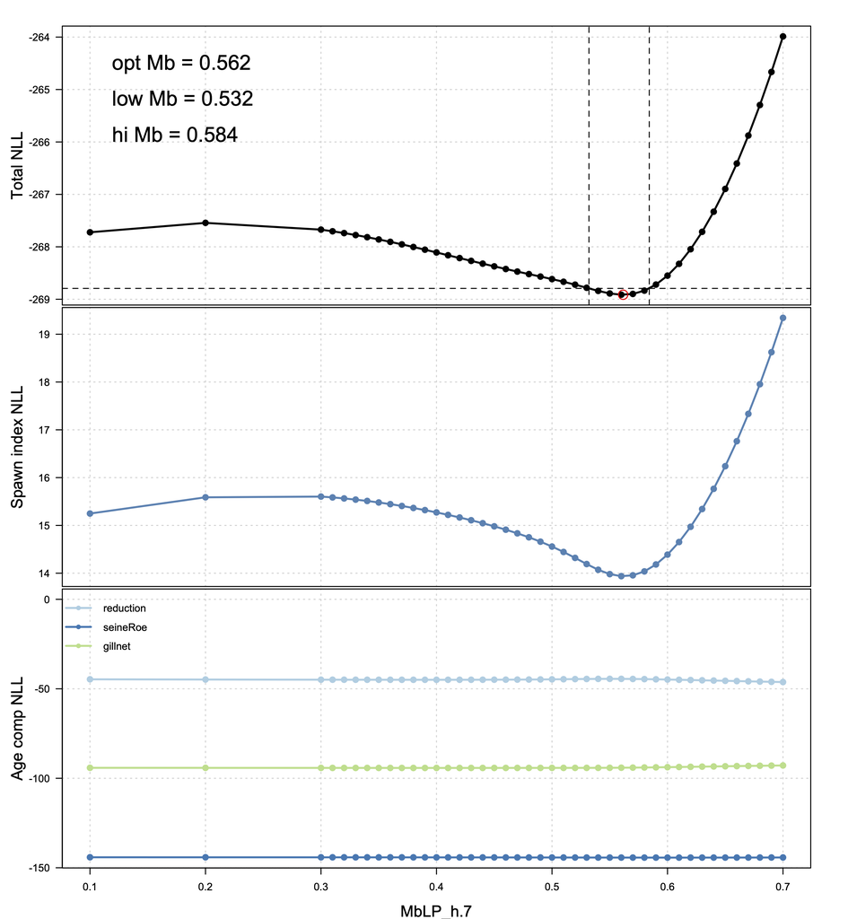

Figure 1: Fishery monitoring data likelihood function profiles relative to a range of natural mortality asymptotic lower limit ($M_b$) parameter values. The red point shows the most likely value, while the two vertical dashed lines show two values with equal likelihood chosen to bound the central OM1. All SISCAH model fits here have a steepness value of $h = 0.7$

## Management Procedures

Management procedures are a combination of data, biomass estimation method (EM), and a havest control rule (HCR).

All MPs tested here use the same data, namely the blended spawn index, commercial fishery catch, and commercial fishery catch-at-age data. The EM, which is fit to those data, is a SISCAH model with a density independent $M$ (DIM) hypothesis, which uses a simple random walk to estimate time-varying $M$. The DIM hypothesis is similar to the previous model used for herring assessments and setting TACs, which used a spline instead of a simple random walk for estimating time-varying $M$. The EM provides annual estimates of unfished biomass and a 1-year ahead forecast of spawning biomass.

TACs are derived from EM estimates via the harvest control rule. For SOG herring, we use the status quo HS 30-60 rule, a “hockey-stick” shaped function with control points at 30% and 60% of unfished biomass. When spawning biomass is estimated to be below the lower control point, the rule sets harvest rates to zero; when biomass estimates are above the upper control point, the rule sets harvest rates to the maximum target harvest rate, called $maxTHR$. We show results for maximum target harvest rates of 6% and 14% (Figure 2).

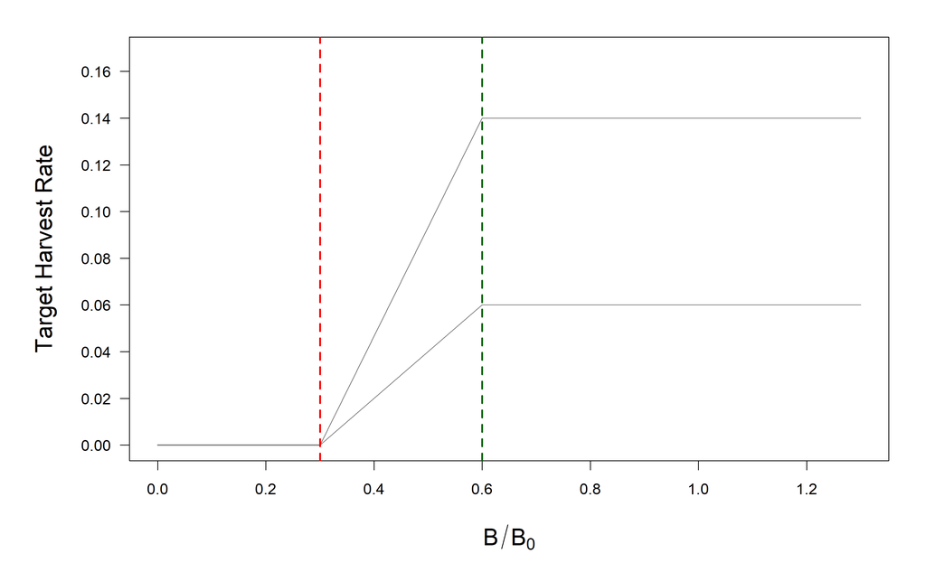

Figure 2: Two harvest control rules tested for candidate SOG herring MPs, showing maximum target harvest rates $maxTHR$ of 6% and 14%.

## Performance metrics

MPs are evaluated against two quantitative management objectives, listed below.

1. $P(B_t > 0.3 B_0) \geq 0.75$, or **avoid the limit reference point (LRP) with high probability over three herring generations.**
2. $P(B_t > USR) \geq 0.5$, or **target the upper stock reference (USR) with neutral probability**.

Objective 1, also known as the conservation objective, must be passed by all herring management procedures. Objective 2 is a target objective related to a recently described provisional $USR$.

To help fishery managers understand trade-offs among biomass and yield, additional quantitative performance metrics are estimated. These metrics do not have a minimum or target value like objectives, but give greater detail on biomass and yield outcomes of each MP over the 15 year simulation.

1. $P(B_t > B_{MSY})$: The probability that biomass is above $B_{MSY}$.
2. $P(U_t > U_{MSY})$: The probability that the effective harvest rate is above $U_{MSY}$.
3. $P(C_t > 650 t)$: The probability of a viable fishery where catch is greater than 650 tonnes.
4. $C_{5pc}$: Catch risk, measured as the fifth percentile of catch over all years and replicates.
5. $\overline{C}$: Median (over replicates) of the average (over years) total landings.
6. $AAV$: Average annual variation in catch, or the mean percentage difference in catch from year-to-year.
7. $C_{2024}$: The MP’s TAC in 2024.
8. $\overline{B_{t}/B_0}$: Average biomass depletion from 2024 - 2038.
9. ${B_{2038}/B_0}$: Median biomass depletion in 2038.
10. $B_{2038}$: Median biomass in 2038.

Performance metrics are estimated via closed loop feedback simulations with the following simulation algorithm:

1. For each Operating Model, initialize a pre-conditioned simulation model for the period 1951 – 2023 based on a random draw from the operating model posterior distribution;
2. Project the operating model population and fishery into the future one time-step at a time. At each step, apply the following:
   1. Generate the catch and spawn survey data available for stock assessment;
   2. Determine 1-year ahead forecast of spawning biomass depletion level from a Density Independent $M$ SISCAH estimation model;
   3. Apply the HS 30-60 harvest control rule wuth to generate a catch limit according to the maximum target harvest rate;
   4. Update the operating model population given the catch limits for each fishery and new recruitment;
   5. Repeat steps 2.i - 2.iv until the projection period ends (2038).
3. Repeat steps 1. and 2. 99 more times;
4. Calculate quantitative performance statistics above across all 100 replicates.

# MP performance and discussion

Harvest rates need to be much lower than $U_{MSY}$ to avoid the LRP with high probability (75% or more). This is because the LRP is quite high relative to $B_{MSY}$ (Table 1, Figure 3), roughly around 70% of $B_{MSY \vert OM1}$ for OM1. For comparison, the default limit reference point in Canadian fisheries policy is 40% of $B_{MSY}$ or some proxy, although this is largely applied to longer lived groundfish species with less variable recruitment and lower predation pressures.

Table 3: Table 4: Performance statistics for the selected harvest rates. Objectives that are passed by an MP are indicated by a bullet. Conservation, Biomass, Overfishing, and Viable Fishery metrics are all in probability units. Catch at Risk 5%, Average Catch, 2024 Catch and Final Biomass are all in biomass units (kt), and Stock Status is biomass depletion relative to unfished (proportion).

| MP | Conservation $B_t \geq 0.3 B_0$ | Biomass $B_t \geq B_{MSY}$ | Biomass $B_t \geq USR$ | Overfishing $U_t \geq U_{MSY}$ | Viable Fishery $C_t \geq 650 t$ | Catch at Risk 5% $C_{5pc}$ | Average Catch $\overline{C}$ | Catch Variability $AAV$ | 2024 Catch $C_{2024}$ | Stock Status $\overline{B_{t}/B_0}$ | Stock Status $B_{2038}/B_0$ | Final Biomass $B_{2038}$ |
| --- | --- | --- | --- | --- | --- | --- | --- | --- | --- | --- | --- | --- |
| maxTHR_0.06 | $\bullet$ | 0.77 | $\bullet$ | 0.04 | 0.96 | 1.15 | 5.91 | 22.50 | 5.88 | 0.85 | 0.87 | 78.21 |
| maxTHR_0.14 | $\bullet$ | 0.63 | 0.35 | 0.37 | 0.95 | 0.49 | 11.83 | 29.38 | 13.72 | 0.66 | 0.61 | 55.18 |

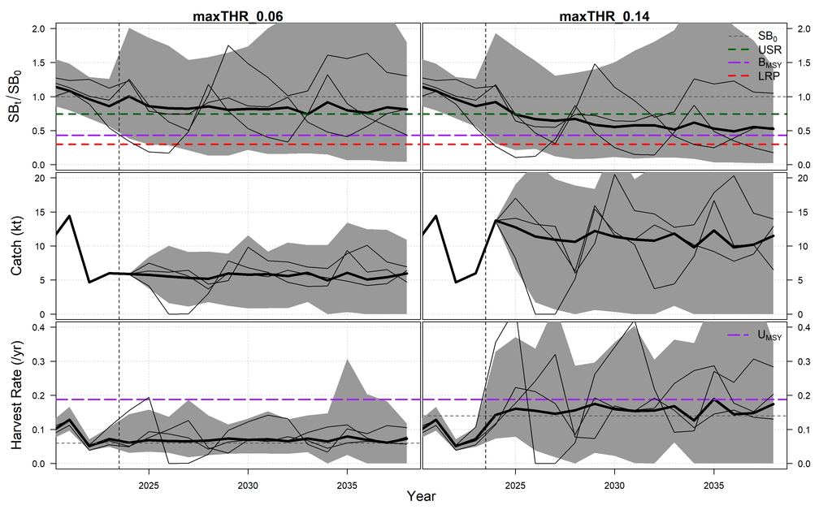

Figure 3: Simulation envelopes of spawning biomass depletion (top row), catch (middle row) and effective harvest rate (bottom row). Each column shows a single MP, labeled in the top margin. Median values are shown by the thick black lines, the grey shaded region shows the central 95% of each envelope, and three randomly selected individual replicate traces are shown as thin black lines.

# Exceptional Circumstances

Fishery monitoring data collected since the adoption of the current SOG herring MP does is within expectations. In formal language, there is no indication of exceptional circumstances (Figure 4), measured by catch and spawn index values within the expected range of previous closed loop simulations.

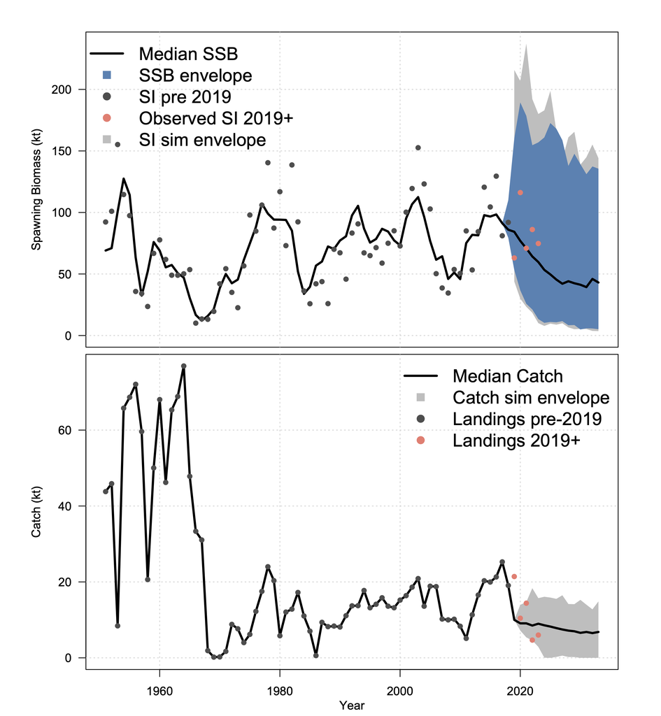

Figure 4: A graphical test for exceptional circumstances, showing the central 95% of projected spawn index values (top) and catch values (bottom) using the 2019 SOG operating model, with realised data in the history (black points) and projection (red points) overlaid.